# Homework 5: Trees

## Predicting ozone levels with Trees and Forests

Given a training and testing data set, objective is to minimize the MSE of O3 predictions on the test set.

```r
train = read.csv("DATA/smogData_train.csv")
#rename o3 so the model doesnt get pissy
train = train[2:11]
names(train)[1] = 'ozone'

#load test data for prediction test
test = read.csv("DATA/smogData_test.csv")
test = test[2:11]
names(test)[1] = 'ozone'
```

For primary exploration of the data lets plot some of this smog and see what we see

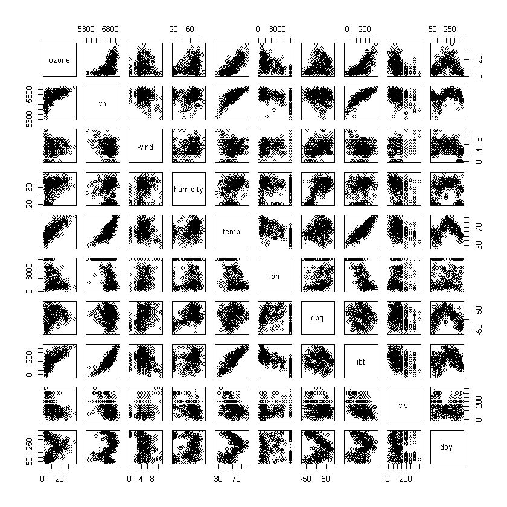

```r
plot(train)
```

Appears to be alot of signal here

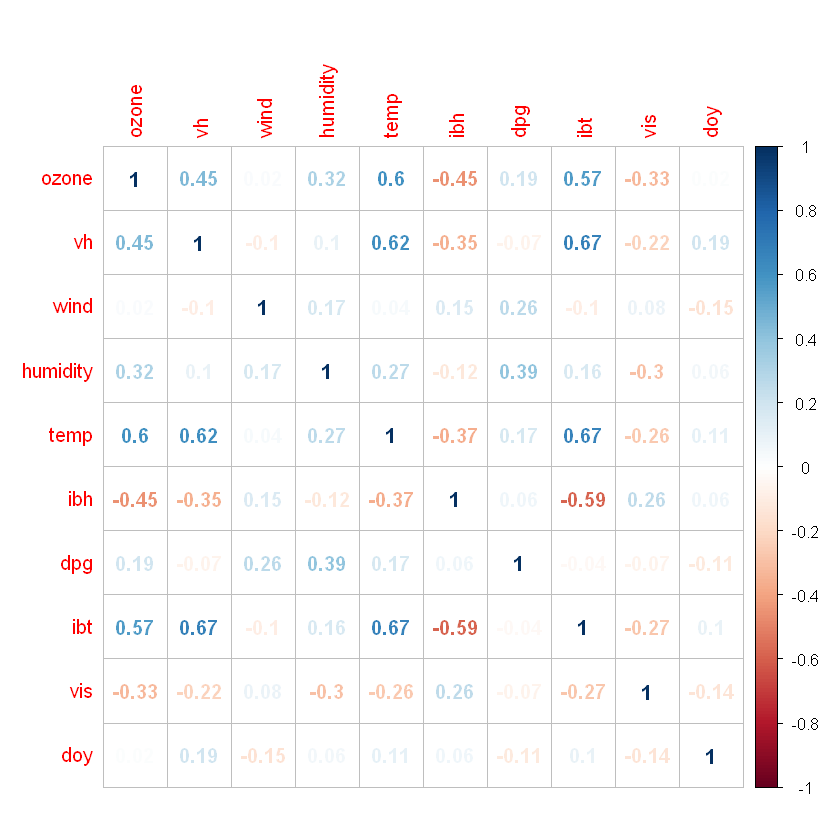

```r
library(corrplot)
train_cors = cor(train[,1:10], method = 'kendall')
corrplot(train_cors, method = "number")
```

## Summary of the correlation matrix

**Correlation to 03:** temp, vh, ibh, ibt  
**Correlated pairs:** temp+vh, temp+ibt, ibh+ibt, vh+ibt

Start by building a simple tree model to visualize the splits

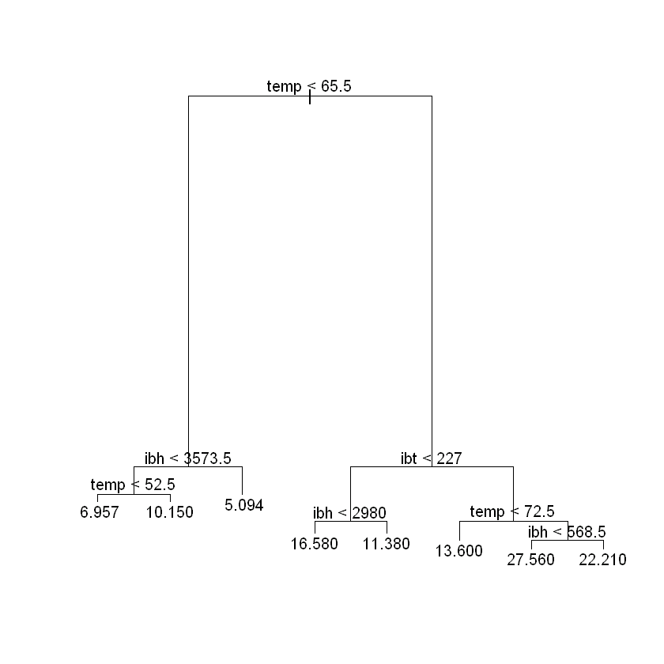

```r
library(tree)
basic_tree = tree(ozone~temp+vh+ibh+ibt, data=train)

plot(basic_tree)
text(basic_tree)
```

## Prediction using Random Forest

```
MSE of Full Tree:  12.48512
```

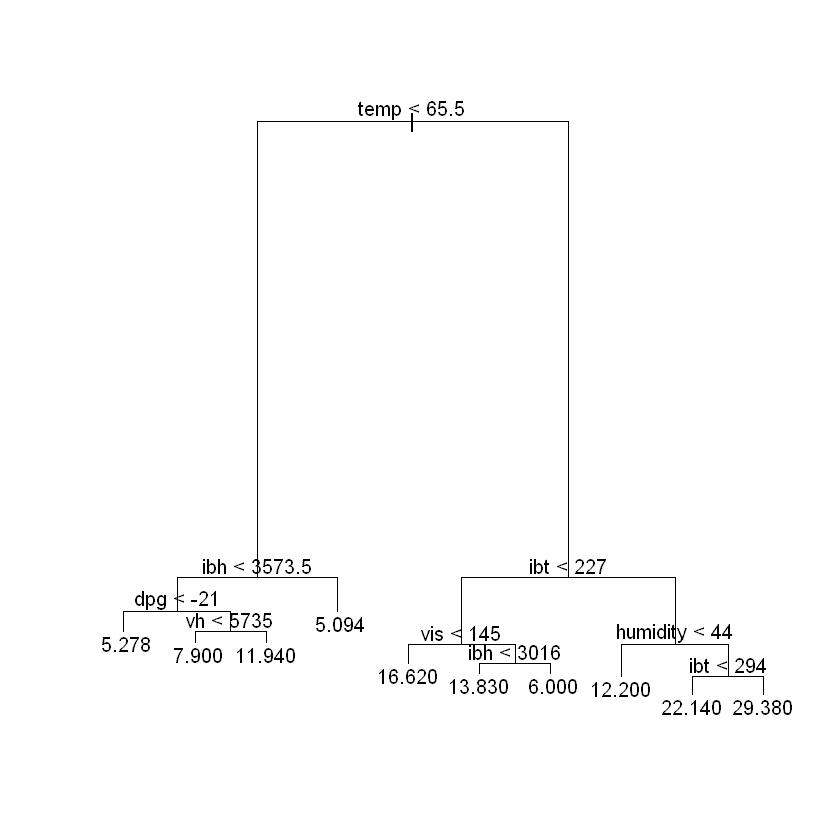

```r
#see if any other variables are included
full_tree = tree(ozone~.,data=train)

plot(full_tree)
text(full_tree)

mse = mean((predict(full_tree, test) - test$ozone)^2)
cat('MSE of Full Tree: ', mse)
```

Very similar trees however extra deviance is explained by using the full set of variables. This gives a good baseline for the mse that can be achieved by simple means.

```
Random Forest #1 MSE: 2.966111
```

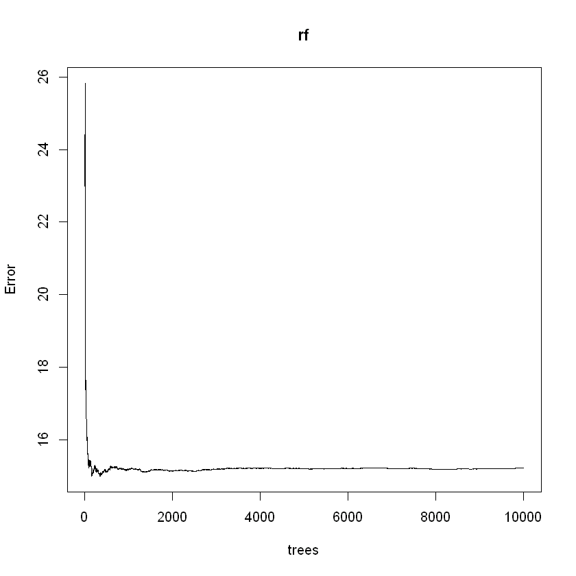

```r
library(randomForest)

rf = randomForest(ozone~., train, ntree=10000, importance=TRUE)
plot(rf)

rf_mse = mean((predict(rf, test) - test$ozone)^2)
cat('Random Forest #1 MSE:', rf_mse)
```

```r
importance(rf)
```

|  | %IncMSE | IncNodePurity |
| --- | --- | --- |
| vh | 50.10897 | 1475.26712 |
| wind | -1.037811 | 178.415205 |
| humidity | 75.63305 | 1086.61444 |
| temp | 107.9234 | 4488.2066 |
| ibh | 71.41055 | 1834.96944 |
| dpg | 77.95634 | 912.80151 |
| ibt | 100.7576 | 3568.0632 |
| vis | 47.61246 | 702.42446 |
| doy | 54.89017 | 730.42244 |

On first run throught of the random forest, we can see that there is a very large decrease in the MSE on the validation set. The VIF table indicates that similar variables that were chosen for the simple tree modle were often favored in the forest

## Using a combination of forrests

```r
rf1 <- randomForest(ozone~., train,ntree=10000, norm.votes=FALSE)
rf2 <- randomForest(ozone~., train,ntree=10000, norm.votes=FALSE)
rf3 <- randomForest(ozone~., train,ntree=10000, norm.votes=FALSE)
rf.all <- combine(rf1, rf2, rf3)

rf.all_mse = mean((predict(rf.all, test) - test$ozone)^2)
cat('Combination simple forest MSE: ',rf.all_mse)
```

```
Combination simple forest MSE:  2.957355
```

Roughly the same MSE is achieved by using this combination very similar to simply increasing the number of trees.

## Parameter Optimization

```
Minimum MSE generated:  2.09046
```

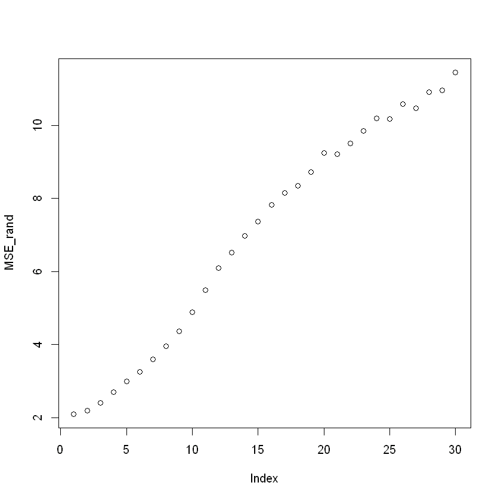

```r
#start with nodesize
MSE_rand = rep(NA,30)
for( i in 1:30){
  temp_opt = randomForest(ozone~., train,ntree=1000, nodesize = i)
  MSE_rand[i] = mean((predict(temp_opt, test) - test$ozone)^2)
}

cat('Minimum MSE generated: ', min(MSE_rand))
plot(MSE_rand)
```

The larger end node has larger MSE, less granular the ability to decrese deviance within nodes.

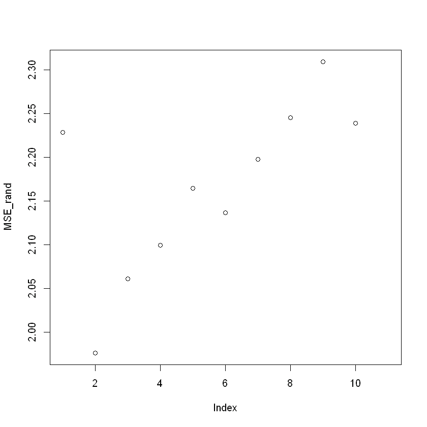

```r
MSE_rand = rep(NA,11)
for (i in 1:10){
  temp_opt = randomForest(ozone~., train,ntree=1000, nodesize = 1, mtry = i)
  MSE_rand[i] = mean((predict(temp_opt, test) - test$ozone)^2)
}
plot(MSE_rand)
```

Using these optimized parameters train a final tree with a large number of trees.

```
Final Forest MSE:  2.015314
```

|  | %IncMSE | IncNodePurity |
| --- | --- | --- |
| vh | 50.10897 | 1475.26712 |
| wind | -1.037811 | 178.415205 |
| humidity | 75.63305 | 1086.61444 |
| temp | 107.9234 | 4488.2066 |
| ibh | 71.41055 | 1834.96944 |
| dpg | 77.95634 | 912.80151 |
| ibt | 100.7576 | 3568.0632 |
| vis | 47.61246 | 702.42446 |
| doy | 54.89017 | 730.42244 |

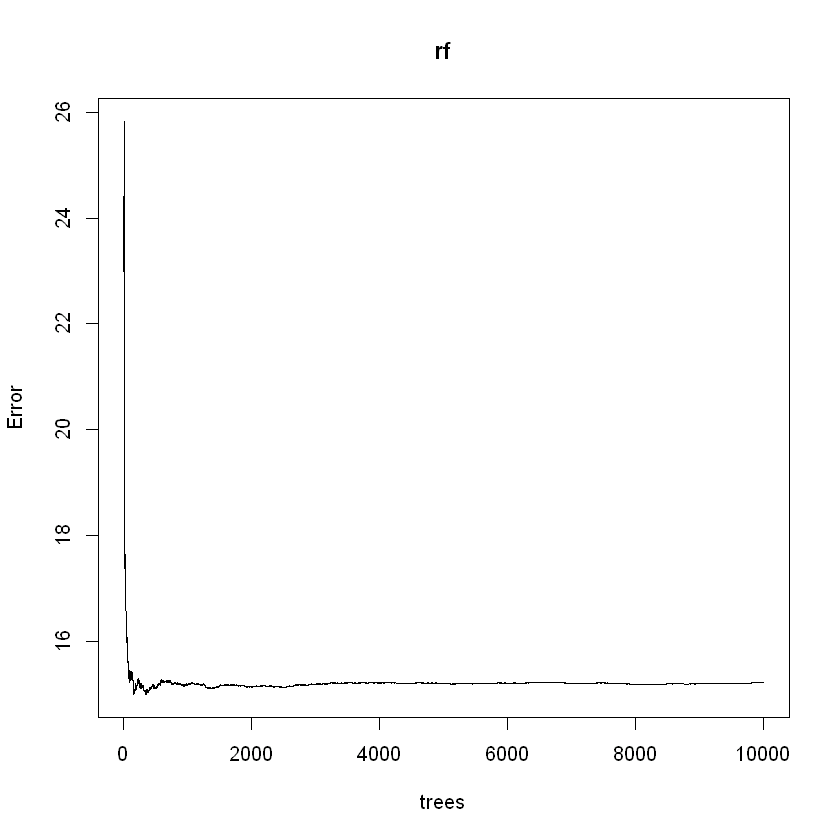

```r
rf_opt = randomForest(ozone~., train,ntree=100000,
                      nodesize = 1, mtry = 2, importance=TRUE)
rf_opt_mse = mean((predict(rf_opt, test) - test$ozone)^2)

cat('Final Forest MSE: ', rf_opt_mse)

plot(rf)
importance(rf)
```

# Modeling with the `caret` package and Cross Validation

### Repeated K-folds

Using the caret package, lets find better results using it's CV capabilities

```r
library(caret)

#start by creating a resampling `trainonrtol` to pass into the train function

fitControl = trainControl(##10-fold cv
                        method = "repeatedcv",
                        number = 10,
                        ## repeated ten times
                        repeats = 10
                        )
```

```r
set.seed(666)
forrest.kfcv = train(ozone ~ ., data = train,
                method = "rf",
                trControl = fitControl,
                verbose = TRUE)
forrest.kfcv
```

```
Random Forest

255 samples
  9 predictor

No pre-processing
Resampling: Cross-Validated (10 fold, repeated 10 times)

Summary of sample sizes: 228, 229, 231, 231, 231, 229, ...

Resampling results across tuning parameters:

  mtry  RMSE      Rsquared   RMSE SD    Rsquared SD
  2     3.838679  0.7694670  0.5919682  0.06802831
  5     3.945174  0.7533950  0.6265706  0.06980117
  9     4.047806  0.7392922  0.6539751  0.07253528

RMSE was used to select the optimal model using  the smallest value.
The final value used for the model was mtry = 2.
```

```
LOOCV Chosen Tree:  3.102911
```

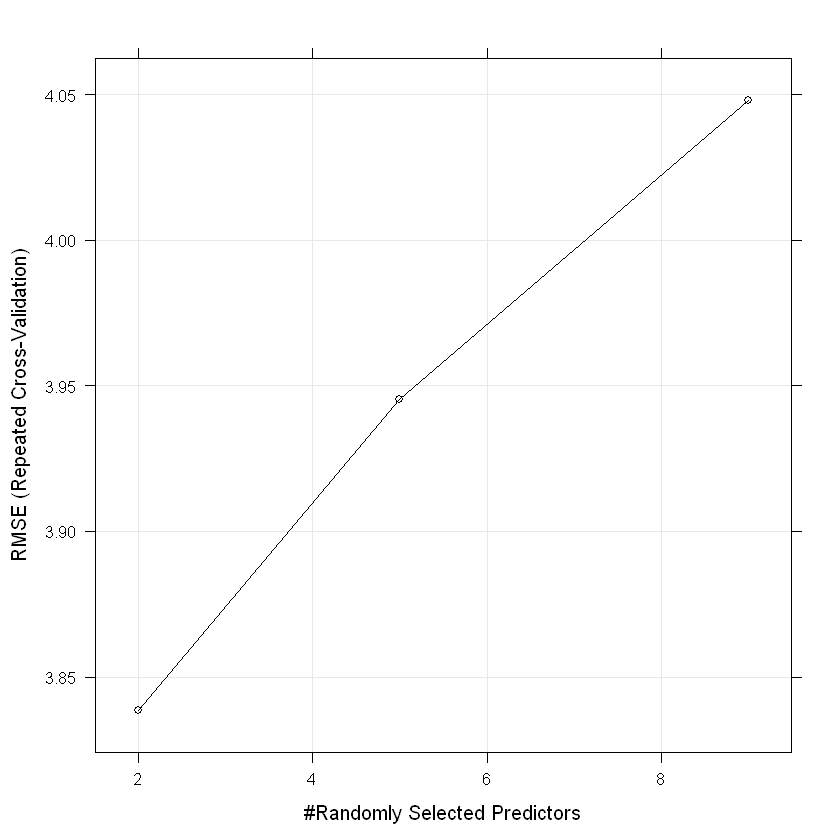

```r
mse_forrest.kfcv = mean((predict(forrest.kfcv, test) - test$ozone)^2)

plot(forrest.kfcv)

cat('LOOCV Chosen Tree: ', mse_forrest.kfcv)
```

Looking at these results, we can see that it we get the same value for `mtry` from above, however this result is probably done in a less gnarly way.

### Leave one out cross validation

Lets now try to refit this model with leave one out cv and see if this produces better results.

```r
LOOcontrol = trainControl(##Leave one out
                        method = "LOOCV"
                       )
```

```r
forrest.loocv = train(ozone ~ ., data = train,
                method = "rf",
                trControl = LOOcontrol,
                verbose = TRUE)
forrest.loocv
```

```
Random Forest

255 samples
  9 predictor

No pre-processing
Resampling:

Summary of sample sizes: 254, 254, 254, 254, 254, 254, ...

Resampling results across tuning parameters:

  mtry  RMSE      Rsquared
  2     3.876456  0.7533726
  5     3.940606  0.7434570
  9     4.062722  0.7274535

RMSE was used to select the optimal model using  the smallest value.
The final value used for the model was mtry = 2.
```

The final `mtry` value chosen for this model using the Leave One Out CV method was again `mtry = 2`. Check these results on the hold out set:

```
LOOCV Chosen Tree:  3.120676
```

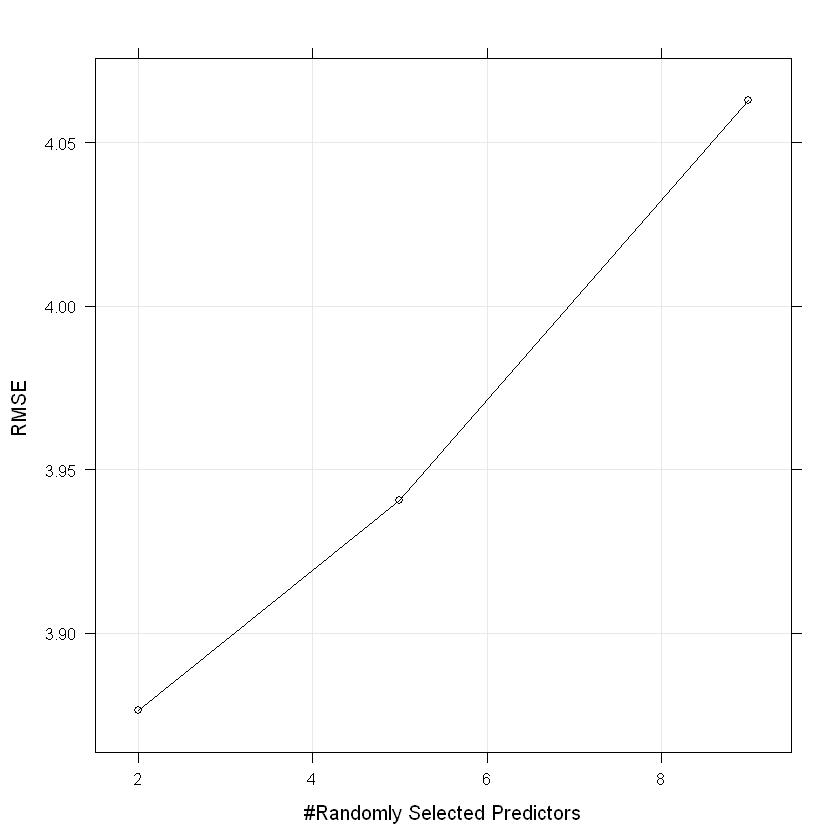

```r
mse_forrest.loocv = mean((predict(forrest.loocv, test) - test$ozone)^2)

plot(forrest.loocv)

cat('LOOCV Chosen Tree: ', mse_forrest.loocv)
```